# NZ CAS dataset preparation for Geospatial Analysis in QGIS & EDA

Data wrangling: Cleaning the dataset and creating a subset for Auckland Region from 2018 onwards.

EDA: Brief exploration of the dataset to extract insights for further geospatial exploration in QGIS

#### Import Libraries, Settings & Loading Data

```python
import pandas as pd
import numpy as np
import matplotlib.pyplot as plt
from matplotlib.colors import Normalize, rgb2hex
import seaborn as sns
import os
from scipy import stats
from scipy.stats import pearsonr
import geopandas as gpd
from shapely.geometry import Point
from shapely.geometry import Polygon
import rasterio
from rasterio.transform import from_origin
import matplotlib.colors as mcolors
from sklearn.cluster import DBSCAN
from sklearn.neighbors import KernelDensity
from sklearn.cluster import KMeans
from sklearn.preprocessing import OneHotEncoder
from sklearn.preprocessing import StandardScaler
#import folium
#from folium.plugins import HeatMap
#from folium.plugins import MarkerCluster
#from folium.plugins import HeatMapWithTime

%matplotlib inline

from pylab import rcParams
rcParams['figure.dpi'] = 150
#rcParams['lines.linewidth'] = 2
rcParams['axes.facecolor'] = 'white'
rcParams['patch.edgecolor'] = 'white'

pd.set_option('display.max_columns', 30)
pd.set_option('display.max_rows', 30)
```

```python
# Load CAS dataset
path = '/Users/lvmacpro/Desktop/CAS_data.csv'
#cas = pd.read_csv(path)

file = 'CAS_data.csv'
cas = pd.read_csv(file)
cas
```

|  | X | Y | OBJECTID | advisorySpeed | areaUnitID | bicycle | bridge | bus | carStationWagon | cliffBank | crashDirectionDescription | crashFinancialYear | crashLocation1 | crashLocation2 | crashRoadSideRoad | ... | tlaId | tlaName | trafficControl | trafficIsland | trafficSign | train | tree | truck | unknownVehicleType | urban | vanOrUtility | vehicle | waterRiver | … |
| --- | --- | --- | --- | --- | --- | --- | --- | --- | --- | --- | --- | --- | --- | --- | --- | --- | --- | --- | --- | --- | --- | --- | --- | --- | --- | --- | --- | --- | --- | --- |
| 0 | 2.037858e+06 | 5.707835e+06 | 1 | NaN | 544801.0 | 0.0 | NaN | 0.0 | 2.0 | NaN | Null | 2011/2012 | SH 35 WAINUI | HIRINI ST | NaN | ... | 28.0 | Gisborne District | Give way | NaN | NaN | NaN | NaN | 0.0 | 0.0 | Urban | 0.0 | NaN | NaN | … |
| 1 | 1.799424e+06 | 5.815528e+06 | 2 | NaN | 528900.0 | 0.0 | NaN | 0.0 | 2.0 | NaN | Null | 2011/2012 | HALL ST | LAKE ROAD | NaN | ... | 16.0 | Hamilton City | Traffic Signals | NaN | NaN | NaN | NaN | 0.0 | 0.0 | Urban | 0.0 | NaN | NaN | … |
| 2 | 1.756461e+06 | 5.936053e+06 | 3 | NaN | 507000.0 | 0.0 | NaN | 0.0 | 0.0 | NaN | Null | 2012/2013 | SHARON ROAD | RIDGE ROAD | NaN | ... | 76.0 | Auckland | Nil | NaN | NaN | NaN | NaN | 0.0 | 0.0 | Urban | 1.0 | NaN | NaN | … |
| 3 | 1.551129e+06 | 5.171320e+06 | 4 | NaN | 597513.0 | 0.0 | 0.0 | 0.0 | 2.0 | 0.0 | Null | 2011/2012 | SPRINGSTON ROLLESTON ROAD | DYNES ROAD | NaN | ... | 62.0 | Selwyn District | Nil | 0.0 | 0.0 | 0.0 | 0.0 | 0.0 | 0.0 | Open | 0.0 | 0.0 | 0.0 | … |
| 4 | 1.245391e+06 | 4.849172e+06 | 5 | NaN | 611500.0 | 0.0 | NaN | 0.0 | 1.0 | NaN | Null | 2011/2012 | TWEED ST | INGLEWOOD ROAD | NaN | ... | 75.0 | Invercargill City | Give way | NaN | NaN | NaN | NaN | 0.0 | 0.0 | Urban | 1.0 | NaN | NaN | … |
| ... | ... | ... | ... | ... | ... | ... | ... | ... | ... | ... | ... | ... | ... | ... | ... | ... | ... | ... | ... | ... | ... | ... | ... | ... | ... | ... | ... | ... | ... | … |
| 821739 | 1.757918e+06 | 5.914599e+06 | 1318959 | NaN | 518600.0 | 0.0 | NaN | 0.0 | 2.0 | NaN | South | 2022/2023 | PAH ROAD | PUKEHANA AVENUE | NaN | ... | 76.0 | Auckland | Nil | NaN | NaN | NaN | NaN | 0.0 | 0.0 | Urban | 0.0 | NaN | NaN | … |
| 821740 | 1.833766e+06 | 5.638669e+06 | 1318960 | NaN | 554900.0 | 0.0 | 0.0 | 0.0 | 0.0 | 0.0 | North | 2022/2023 | SH 1 | ACCESS ROAD NO 17 | NaN | ... | 36.0 | Ruapehu District | Nil | 0.0 | 0.0 | 0.0 | 1.0 | 0.0 | 0.0 | Open | 0.0 | 0.0 | 0.0 | … |
| 821741 | 1.758255e+06 | 5.918060e+06 | 1318961 | NaN | 517400.0 | 0.0 | 0.0 | 0.0 | 1.0 | 0.0 | East | 2022/2023 | MORROW STREET | GILLIES AVENUE | NaN | ... | 76.0 | Auckland | Nil | 0.0 | 1.0 | 0.0 | 0.0 | 0.0 | 0.0 | Urban | 0.0 | 0.0 | 0.0 | … |
| 821742 | 1.773738e+06 | 5.888266e+06 | 1318962 | NaN | NaN | 0.0 | 0.0 | 0.0 | 0.0 | 0.0 | North | 2022/2023 | GREAT SOUTH ROAD | WAIMANU AWA ROAD | NaN | ... | NaN | NaN | Nil | 0.0 | 0.0 | 0.0 | 0.0 | 0.0 | 0.0 | Open | 1.0 | 0.0 | 0.0 | … |
| 821743 | 1.754396e+06 | 5.875116e+06 | 1318963 | NaN | 526104.0 | 0.0 | 0.0 | 0.0 | 1.0 | 0.0 | Null | 2022/2023 | KAIWAKA ROAD | COLOMBO ROAD | NaN | ... | 76.0 | Auckland | Give way | 0.0 | 0.0 | 0.0 | 0.0 | 0.0 | 0.0 | Urban | 0.0 | 0.0 | 0.0 | … |

821744 rows × 72 columns

### Data Wrangling & Quality Check

```python
cas.columns
```

```
Index(['X', 'Y', 'OBJECTID', 'advisorySpeed', 'areaUnitID', 'bicycle',
       'bridge', 'bus', 'carStationWagon', 'cliffBank',
       'crashDirectionDescription', 'crashFinancialYear', 'crashLocation1',
       'crashLocation2', 'crashRoadSideRoad', 'crashSeverity',
       'crashSHDescription', 'crashYear', 'debris', 'directionRoleDescription',
       'ditch', 'fatalCount', 'fence', 'flatHill', 'guardRail', 'holiday',
       'houseOrBuilding', 'intersection', 'kerb', 'light', 'meshblockId',
       'minorInjuryCount', 'moped', 'motorcycle', 'NumberOfLanes',
       'objectThrownOrDropped', 'otherObject', 'otherVehicleType', 'overBank',
       'parkedVehicle', 'pedestrian', 'phoneBoxEtc', 'postOrPole', 'region',
       'roadCharacter', 'roadLane', 'roadSurface', 'roadworks', 'schoolBus',
       'seriousInjuryCount', 'slipOrFlood', 'speedLimit', 'strayAnimal',
       'streetLight', 'suv', 'taxi', 'temporarySpeedLimit', 'tlaId', 'tlaName',
       'trafficControl', 'trafficIsland', 'trafficSign', 'train', 'tree',
       'truck', 'unknownVehicleType', 'urban', 'vanOrUtility', 'vehicle',
       'waterRiver', 'weatherA', 'weatherB'],
      dtype='object')
```

```python
# List unique values in the specified columns
crash_years = cas['crashYear'].unique()
regions = cas['region'].unique()

# Display the unique values
print("Unique values in 'crashYear':")
print(crash_years)
print("\nUnique values in 'region':")
print(regions)
```

```
Unique values in 'crashYear':
[2011 2012 2013 2014 2015 2016 2000 2001 2002 2003 2004 2005 2006 2007
 2008 2009 2010 2017 2018 2019 2020 2021 2022 2023]

Unique values in 'region':
['Gisborne Region' 'Waikato Region' 'Auckland Region' 'Canterbury Region'
 'Southland Region' 'Otago Region' 'Wellington Region'
 'Manawatū-Whanganui Region' 'Bay of Plenty Region' 'Northland Region'
 'West Coast Region' 'Taranaki Region' nan "Hawke's Bay Region"
 'Tasman Region' 'Nelson Region' 'Marlborough Region']
```

Dropping all regions other than Auckland and NaN. Next step is to find if there are any NaN rows that actually belong in Auckland region. I will do that by trying to match their area unit IDs.

```python
# Filter the dataset to keep only rows where 'region' is 'Auckland Region' or NaN
cas_Auckland = cas[(cas['region'] == 'Auckland Region') | (cas['region'].isna())]

print(f"\nNumber of rows in the filtered dataset: {len(cas_Auckland)}")

nan_region = cas_Auckland[cas_Auckland['region'].isna()]
print(f"\nNumber of NaN regions in the dataset: {len(nan_region)}")
```

```
Number of rows in the filtered dataset: 288534

Number of NaN regions in the dataset: 3188
```

Searching for rows that currently have no region (Nan) but their areaUnitID matches those of Auckland Region, or Territorial Id or Name. Thus, I assume the accidents occurred in Auckland region and therefore will impute the region, tlaId and tlaName to Auckland. Printing the rows that got the region modified to Auckland.

```python
# Step 1: Identify areaUnitID, tlaID, and tlaName values where the region is 'Auckland Region'
akl_area_unit_ids = cas_Auckland[cas_Auckland['region'] == 'Auckland Region']['areaUnitID'].unique()
akl_tla_ids = cas_Auckland[cas_Auckland['region'] == 'Auckland Region']['tlaId'].unique()
akl_tla_names = cas_Auckland[cas_Auckland['region'] == 'Auckland Region']['tlaName'].unique()

# Step 2: Filter cas_AKL to get rows where region is NaN and any of the areaUnitID, tlaID, or tlaName matches
nan_region_matching = cas_Auckland[cas_Auckland['region'].isna() & (
    cas_Auckland['areaUnitID'].isin(akl_area_unit_ids) |
    cas_Auckland['tlaId'].isin(akl_tla_ids) |
    cas_Auckland['tlaName'].isin(akl_tla_names)
)]

# Step 3: Update the region of these rows to 'Auckland Region'
cas_Auckland.loc[nan_region_matching.index, 'region'] = 'Auckland Region'
cas_Auckland.loc[nan_region_matching.index, 'tlaId'] = 76
cas_Auckland.loc[nan_region_matching.index, 'tlaName'] = 'Auckland'

# Print the number of updated regions
print(f"\nNumber of NaN regions updated to 'Auckland Region': {len(nan_region_matching)}")
```

```
Number of NaN regions updated to 'Auckland Region': 2493
```

```python
# Drop all rows where 'region' is NaN
CAS_AKL = cas_Auckland.dropna(subset=['region'])

# NaN rows being dropped
new_nan_region = cas_Auckland[cas_Auckland['region'].isna()]

print(f"\nNumber of rows in our augmented Auckland Region dataset: {len(CAS_AKL)}")
print(f"\nNumber of NaN added to Auckland: {len(nan_region_matching)}")
print(f"\nNumber of NaN rows dropped: {len(new_nan_region)}")
CAS_AKL
```

```
Number of rows in our augmented Auckland Region dataset: 287839

Number of NaN added to Auckland: 2493

Number of NaN rows dropped: 695
```

|  | X | Y | OBJECTID | advisorySpeed | areaUnitID | bicycle | bridge | bus | carStationWagon | cliffBank | crashDirectionDescription | crashFinancialYear | crashLocation1 | crashLocation2 | crashRoadSideRoad | ... | tlaId | tlaName | trafficControl | trafficIsland | trafficSign | train | tree | truck | unknownVehicleType | urban | vanOrUtility | vehicle | waterRiver | … |
| --- | --- | --- | --- | --- | --- | --- | --- | --- | --- | --- | --- | --- | --- | --- | --- | --- | --- | --- | --- | --- | --- | --- | --- | --- | --- | --- | --- | --- | --- | --- |
| 2 | 1.756461e+06 | 5.936053e+06 | 3 | NaN | 507000.0 | 0.0 | NaN | 0.0 | 0.0 | NaN | Null | 2012/2013 | SHARON ROAD | RIDGE ROAD | NaN | ... | 76.0 | Auckland | Nil | NaN | NaN | NaN | NaN | 0.0 | 0.0 | Urban | 1.0 | NaN | NaN | … |
| 7 | 1.772256e+06 | 5.896393e+06 | 8 | NaN | 525420.0 | 0.0 | NaN | 0.0 | 1.0 | NaN | Null | 2011/2012 | GREEN ST | QUEEN ST | NaN | ... | 76.0 | Auckland | Nil | NaN | NaN | NaN | NaN | 1.0 | 0.0 | Urban | 0.0 | NaN | NaN | … |
| 9 | 1.766897e+06 | 5.907471e+06 | 10 | NaN | 523601.0 | 0.0 | 0.0 | 0.0 | 2.0 | 0.0 | South | 2011/2012 | BAIRDS ROAD | JUKES PLACE | NaN | ... | 76.0 | Auckland | Nil | 0.0 | 0.0 | 0.0 | 0.0 | 0.0 | 0.0 | Urban | 0.0 | 1.0 | 0.0 | … |
| 10 | 1.754057e+06 | 5.936391e+06 | 11 | NaN | 506902.0 | 0.0 | NaN | 0.0 | 2.0 | NaN | Null | 2011/2012 | EAST COAST ROAD | GLAMORGAN DRIVE | NaN | ... | 76.0 | Auckland | Nil | NaN | NaN | NaN | NaN | 0.0 | 0.0 | Urban | 0.0 | NaN | NaN | … |
| 13 | 1.772574e+06 | 5.901427e+06 | 14 | NaN | 523813.0 | 0.0 | NaN | 0.0 | 2.0 | NaN | South | 2011/2012 | MILL ROAD | ALFRISTON ROAD | NaN | ... | 76.0 | Auckland | Nil | NaN | NaN | NaN | NaN | 0.0 | 0.0 | Open | 0.0 | NaN | NaN | … |
| ... | ... | ... | ... | ... | ... | ... | ... | ... | ... | ... | ... | ... | ... | ... | ... | ... | ... | ... | ... | ... | ... | ... | ... | ... | ... | ... | ... | ... | ... | … |
| 821736 | 1.743947e+06 | 5.924009e+06 | 1318956 | NaN | 513511.0 | 0.0 | NaN | 0.0 | 2.0 | NaN | Null | 2022/2023 | FRED TAYLOR DRIVE | HOBSONVILLE ROAD | NaN | ... | 76.0 | Auckland | Give way | NaN | NaN | NaN | NaN | 0.0 | 0.0 | Urban | 0.0 | NaN | NaN | … |
| 821737 | 1.768891e+06 | 5.904246e+06 | 1318957 | NaN | 523820.0 | 0.0 | 0.0 | 0.0 | 2.0 | 0.0 | Null | 2022/2023 | RANSOM SMYTH DRIVE | PALMETTO PLACE | NaN | ... | 76.0 | Auckland | Nil | 0.0 | 0.0 | 0.0 | 0.0 | 0.0 | 0.0 | Urban | 0.0 | 0.0 | 0.0 | … |
| 821739 | 1.757918e+06 | 5.914599e+06 | 1318959 | NaN | 518600.0 | 0.0 | NaN | 0.0 | 2.0 | NaN | South | 2022/2023 | PAH ROAD | PUKEHANA AVENUE | NaN | ... | 76.0 | Auckland | Nil | NaN | NaN | NaN | NaN | 0.0 | 0.0 | Urban | 0.0 | NaN | NaN | … |
| 821741 | 1.758255e+06 | 5.918060e+06 | 1318961 | NaN | 517400.0 | 0.0 | 0.0 | 0.0 | 1.0 | 0.0 | East | 2022/2023 | MORROW STREET | GILLIES AVENUE | NaN | ... | 76.0 | Auckland | Nil | 0.0 | 1.0 | 0.0 | 0.0 | 0.0 | 0.0 | Urban | 0.0 | 0.0 | 0.0 | … |
| 821743 | 1.754396e+06 | 5.875116e+06 | 1318963 | NaN | 526104.0 | 0.0 | 0.0 | 0.0 | 1.0 | 0.0 | Null | 2022/2023 | KAIWAKA ROAD | COLOMBO ROAD | NaN | ... | 76.0 | Auckland | Give way | 0.0 | 0.0 | 0.0 | 0.0 | 0.0 | 0.0 | Urban | 0.0 | 0.0 | 0.0 | … |

287839 rows × 72 columns

```python
CAS_AKL = CAS_AKL.copy()

# columns to be summed for vehicle_sum
vehicle_cols = ['bicycle', 'bus', 'carStationWagon', 'moped', 'motorcycle',
                   'otherVehicleType', 'parkedVehicle', 'schoolBus',
                   'suv', 'taxi', 'train', 'truck', 'unknownVehicleType', 'vanOrUtility', 'vehicle']

# Create a new column 'vehicle_sum' by summing the specified columns
CAS_AKL.loc[:, 'vehicle_sum'] = CAS_AKL[vehicle_cols].sum(axis=1)

CAS_AKL[['bicycle', 'bus', 'carStationWagon', 'moped', 'motorcycle',
                   'otherVehicleType', 'parkedVehicle', 'schoolBus',
                   'suv', 'taxi', 'train', 'truck', 'unknownVehicleType',
                   'vanOrUtility', 'vehicle', 'pedestrian', 'vehicle_sum']].head(3)
```

|  | bicycle | bus | carStationWagon | moped | motorcycle | otherVehicleType | parkedVehicle | schoolBus | suv | taxi | train | truck | unknownVehicleType | vanOrUtility | vehicle | pedestrian | vehicle_sum |
| --- | --- | --- | --- | --- | --- | --- | --- | --- | --- | --- | --- | --- | --- | --- | --- | --- | --- |
| 2 | 0.0 | 0.0 | 0.0 | 0.0 | 0.0 | 0.0 | NaN | 0.0 | 0.0 | 0.0 | NaN | 0.0 | 0.0 | 1.0 | NaN | 1.0 | 1.0 |
| 7 | 0.0 | 0.0 | 1.0 | 0.0 | 0.0 | 0.0 | NaN | 0.0 | 0.0 | 0.0 | NaN | 1.0 | 0.0 | 0.0 | NaN | NaN | 2.0 |
| 9 | 0.0 | 0.0 | 2.0 | 0.0 | 0.0 | 0.0 | 0.0 | 0.0 | 0.0 | 0.0 | 0.0 | 0.0 | 0.0 | 0.0 | 1.0 | NaN | 3.0 |

### Filtering Accidents after 2018 (subset)

```python
# Filter the DataFrame for rows where crashYear is greater than 2018
CAS_AKL18 = CAS_AKL[CAS_AKL['crashYear'] >= 2018]
CAS_AKL18 = CAS_AKL18.reset_index(drop=True) #reset index

len_CAS_AKL18 = len(CAS_AKL18)
print(f"Total crashes reported in Auckland from 2018 until 16 May 2024: {len_CAS_AKL18}")
```

```
Total crashes reported in Auckland from 2018 until 16 May 2024: 54807
```

Investigating the odd crashes where neither vehicles nor pedestrians were reported, just the accident!

```python
odd_ped = CAS_AKL18[(CAS_AKL18['pedestrian'].isna()) & (CAS_AKL18['vehicle_sum'] == 0)]
odd_ped.count()
```

```
X                60
Y                60
OBJECTID         60
advisorySpeed     3
areaUnitID       60
                 ..
vehicle          52
waterRiver       52
weatherA         60
weatherB         60
vehicle_sum      60
Length: 73, dtype: int64
```

```python
odd_veh = CAS_AKL18[CAS_AKL18['vehicle_sum'] == 0]
odd_veh.count()
```

```
X                128
Y                128
OBJECTID         128
advisorySpeed      5
areaUnitID       128
                ...
vehicle           56
waterRiver        56
weatherA         128
weatherB         128
vehicle_sum      128
Length: 73, dtype: int64
```

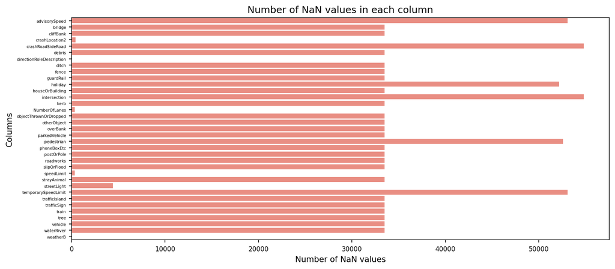

```python
# Calculate the number of NaN values for each column
nan_counts = CAS_AKL18.isna().sum()
nan_counts = nan_counts[nan_counts > 0].reset_index()
nan_counts.columns = ['Column', 'NaN Count']

# Plot the NaN values as a horizontal bar plot
plt.figure(figsize=(12, 5))
sns.barplot(x='NaN Count', y='Column', data=nan_counts, color='salmon')
plt.title('Number of NaN values in each column')
plt.xlabel('Number of NaN values')
plt.ylabel('Columns')
plt.xticks(fontsize=8)
plt.yticks(fontsize=5)
plt.show()
```

The fact that many variables have identical number of missing values indicates that it is likely that these variables have been introduced more recently, or were only being reported by specific patrol areas. Dropping columns with more than 50% missing data. Unfortunately, the dataset does not come with more temporal data such as time of the accident, which would provide room for further temporal analysis. Similarly, we have no details of the drivers involved, such as age, most likely due to privacy reasons.

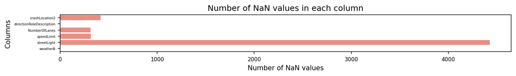

```python
# Calculate the threshold for missing values (at least 50% missing data)
threshold = len(CAS_AKL18) * 0.5

CAS_AKL18 = CAS_AKL18.dropna(thresh=threshold, axis=1)

# Calculate the number of NaN values for each column
nan_counts = CAS_AKL18.isna().sum()
nan_counts = nan_counts[nan_counts > 0].reset_index()
nan_counts.columns = ['Column', 'NaN Count']

# Plot the NaN values as a horizontal bar plot
plt.figure(figsize=(12, 1))
sns.barplot(x='NaN Count', y='Column', data=nan_counts, color='salmon')
plt.title('Number of NaN values in each column')
plt.xlabel('Number of NaN values')
plt.ylabel('Columns')
plt.xticks(fontsize=8)
plt.yticks(fontsize=5)
plt.show()
```

### Creating a new column Severity Index

Initially I was considering using the Belgium severity index (weights: 5 for fatalities, 3 for serious injuries, 1 for minor injuries) to represent accident severity, but given that we have a different split in 4 categories: Fatal Crash, Serious Crash, Minor Crash, Non-Injury Crash, I thought using the New South Wales Road Safety and Traffic Authority's crash severity index as follows:

Severity Index = 3 * Fatal Crash + 1.8 * Serious Crash + 1.3 * Minor Crash + 1 * Non-Injury Crash

Later I realised we also have the number of fatalities, and injuries. Thus, I decided to devise a novel approach combining both the Belgium and Australian. Crash Weights gives higher weight to crashes with fatalities and serious injuries. Severity Index includes the severity and crash weights to provide a more comprehensive severity score.

**Crash Weights = 1 + (5 * fatalCount + 3 * seriousInjuryCount + 1 * minorInjuryCount) / 100**

This approach ensures the severity index reflects both the type of crash and the number of injuries and fatalities involved, providing a more accurate measure of crash severity. However, there are entries that might be missing correct input of number of fatalities and injuries, meaning they will be under represented, but I assume the data should be correct in the system.

References:

Van Raemdonck, K., & Macharis, C. (2014). The road accident analyzer: a tool to identify high-risk road locations. *Journal of Transportation Safety & Security, 6*(2), 130-151.

NSW Road Safety, Traffic Management Directorate. (1999). *Road traffic accidents in New South Wales–1997: Statistical statement: Year ended 31 December 1997.* Roads and Traffic Authority of NSW.

```python
# Calculate Crash Weights
CAS_AKL18['crashWeights'] = 1+ (5 * CAS_AKL18['fatalCount'] + 3 * CAS_AKL18['seriousInjuryCount'] + 1 * CAS_AKL18['minorInjuryCount']) / 100

# Map crash severity to numerical values
severity = {
    'Fatal Crash': 3,
    'Serious Crash': 1.8,
    'Minor Crash': 1.3,
    'Non-Injury Crash': 1,
}

# Create a new column for the mapped values
CAS_AKL18['Severity'] = CAS_AKL18['crashSeverity'].map(severity)

# Calculate the Severity Index
CAS_AKL18['severityIndex'] = CAS_AKL18['Severity'] * CAS_AKL18['crashWeights']

CAS_AKL18.head()
```

|  | X | Y | OBJECTID | areaUnitID | bicycle | bus | carStationWagon | crashDirectionDescription | crashFinancialYear | crashLocation1 | crashLocation2 | crashSeverity | crashSHDescription | crashYear | directionRoleDescription | ... | suv | taxi | tlaId | tlaName | trafficControl | truck | unknownVehicleType | urban | vanOrUtility | weatherA | weatherB | vehicle_sum | crashWeights | … |
| --- | --- | --- | --- | --- | --- | --- | --- | --- | --- | --- | --- | --- | --- | --- | --- | --- | --- | --- | --- | --- | --- | --- | --- | --- | --- | --- | --- | --- | --- | --- |
| 0 | 1754689.0 | 5924770.0 | 141653 | 509800.0 | 0.0 | 0.0 | 3.0 | East | 2017/2018 | ONEWA ROAD | KAURI GLEN ROAD | Minor Crash | No | 2018 | East | ... | 0.0 | 0.0 | 76.0 | Auckland | Unknown | 0.0 | 0.0 | Urban | 0.0 | Light rain | Null | 4.0 | 1.01 | … |
| 1 | 1763714.0 | 5913506.0 | 141723 | 520402.0 | 0.0 | 0.0 | 1.0 | North | 2018/2019 | MOUNT WELLINGTON HIGHWAY | HAMLIN ROAD | Serious Crash | No | 2018 | South | ... | 0.0 | 0.0 | 76.0 | Auckland | Unknown | 0.0 | 0.0 | Urban | 0.0 | Fine | Null | 1.0 | 1.06 | … |
| 2 | 1762166.0 | 5906172.0 | 141727 | 524200.0 | 0.0 | 0.0 | 2.0 | South | 2018/2019 | SH 20 | MASSEY OFF NBD | Minor Crash | Yes | 2018 | North | ... | 0.0 | 0.0 | 76.0 | Auckland | Unknown | 0.0 | 0.0 | Open | 0.0 | Fine | Null | 2.0 | 1.01 | … |
| 3 | 1756323.0 | 5927364.0 | 141728 | 507900.0 | 0.0 | 0.0 | 3.0 | South | 2017/2018 | SH 1N | NORTHCOTE OFF SBD | Minor Crash | Yes | 2018 | South | ... | 0.0 | 0.0 | 76.0 | Auckland | Unknown | 0.0 | 0.0 | Open | 0.0 | Heavy rain | Null | 3.0 | 1.02 | … |
| 4 | 1765783.0 | 5906821.0 | 141750 | 522301.0 | 0.0 | 0.0 | 1.0 | East | 2018/2019 | HOTEO AVENUE | GREAT SOUTH ROAD | Minor Crash | No | 2018 | East | ... | 0.0 | 0.0 | 76.0 | Auckland | Unknown | 0.0 | 0.0 | Urban | 0.0 | Fine | Null | 1.0 | 1.01 | … |

5 rows × 47 columns

## EDA

```python
CAS_AKL18.describe()
```

|  | X | Y | OBJECTID | areaUnitID | bicycle | bus | carStationWagon | crashYear | fatalCount | meshblockId | minorInjuryCount | moped | motorcycle | NumberOfLanes | otherVehicleType | schoolBus | seriousInjuryCount | speedLimit | suv | taxi | tlaId | truck | unknownVehicleType | vanOrUtility | vehicle_sum | crashWeights | Severity | severityIndex |
| --- | --- | --- | --- | --- | --- | --- | --- | --- | --- | --- | --- | --- | --- | --- | --- | --- | --- | --- | --- | --- | --- | --- | --- | --- | --- | --- | --- | --- |
| count | 5.480700e+04 | 5.480700e+04 | 5.480700e+04 | 54807.000000 | 54807.000000 | 54807.000000 | 54807.000000 | 54807.000000 | 54807.000000 | 5.480700e+04 | 54807.000000 | 54807.000000 | 54807.000000 | 54495.000000 | 54807.000000 | 54807.000000 | 54807.000000 | 54492.000000 | 54807.000000 | 54807.000000 | 54807.0 | 54807.000000 | 54807.000000 | 54807.000000 | 54807.000000 | 54807.000000 | 54807.000000 | 54807.000000 |
| mean | 1.759197e+06 | 5.915241e+06 | 7.496665e+05 | 517448.427208 | 0.023282 | 0.021548 | 1.336581 | 2019.888335 | 0.004707 | 5.218859e+05 | 0.334994 | 0.006824 | 0.044210 | 2.583852 | 0.005054 | 0.001022 | 0.054920 | 61.374404 | 0.163665 | 0.011367 | 76.0 | 0.080519 | 0.015564 | 0.192165 | 2.066689 | 1.005233 | 1.126473 | 1.134671 |
| std | 9.513305e+03 | 1.470301e+04 | 3.748120e+05 | 6051.959186 | 0.156031 | 0.146953 | 0.823647 | 1.468624 | 0.072085 | 2.292159e+05 | 0.618263 | 0.082547 | 0.210734 | 1.071340 | 0.072188 | 0.031949 | 0.253094 | 19.780513 | 0.405684 | 0.109731 | 0.0 | 0.286598 | 0.128554 | 0.432802 | 0.931583 | 0.010741 | 0.238184 | 0.257465 |
| min | 1.706526e+06 | 5.871774e+06 | 1.416530e+05 | 505010.000000 | 0.000000 | 0.000000 | 0.000000 | 2018.000000 | 0.000000 | 1.341000e+05 | 0.000000 | 0.000000 | 0.000000 | 0.000000 | 0.000000 | 0.000000 | 0.000000 | 2.000000 | 0.000000 | 0.000000 | 76.0 | 0.000000 | 0.000000 | 0.000000 | 0.000000 | 1.000000 | 1.000000 | 1.000000 |
| 25% | 1.753665e+06 | 5.907074e+06 | 4.770730e+05 | 513301.000000 | 0.000000 | 0.000000 | 1.000000 | 2019.000000 | 0.000000 | 3.079000e+05 | 0.000000 | 0.000000 | 0.000000 | 2.000000 | 0.000000 | 0.000000 | 0.000000 | 50.000000 | 0.000000 | 0.000000 | 76.0 | 0.000000 | 0.000000 | 0.000000 | 1.000000 | 1.000000 | 1.000000 | 1.000000 |
| 50% | 1.758856e+06 | 5.914484e+06 | 8.085350e+05 | 518701.000000 | 0.000000 | 0.000000 | 1.000000 | 2020.000000 | 0.000000 | 5.618000e+05 | 0.000000 | 0.000000 | 0.000000 | 2.000000 | 0.000000 | 0.000000 | 0.000000 | 50.000000 | 0.000000 | 0.000000 | 76.0 | 0.000000 | 0.000000 | 0.000000 | 2.000000 | 1.000000 | 1.000000 | 1.000000 |
| 75% | 1.766334e+06 | 5.920147e+06 | 1.142944e+06 | 523113.000000 | 0.000000 | 0.000000 | 2.000000 | 2021.000000 | 0.000000 | 7.196505e+05 | 1.000000 | 0.000000 | 0.000000 | 3.000000 | 0.000000 | 0.000000 | 0.000000 | 80.000000 | 0.000000 | 0.000000 | 76.0 | 0.000000 | 0.000000 | 0.000000 | 2.000000 | 1.010000 | 1.300000 | 1.313000 |
| max | 1.823969e+06 | 6.000240e+06 | 1.318963e+06 | 526105.000000 | 5.000000 | 2.000000 | 10.000000 | 2023.000000 | 2.000000 | 3.209003e+06 | 7.000000 | 2.000000 | 3.000000 | 9.000000 | 2.000000 | 1.000000 | 6.000000 | 110.000000 | 3.000000 | 2.000000 | 76.0 | 4.000000 | 3.000000 | 4.000000 | 17.000000 | 1.240000 | 3.000000 | 3.720000 |

```python
CAS_AKL18.describe(include=['object'])
```

|  | crashDirectionDescription | crashFinancialYear | crashLocation1 | crashLocation2 | crashSeverity | crashSHDescription | directionRoleDescription | flatHill | light | region | roadCharacter | roadLane | roadSurface | streetLight | tlaName | trafficControl | urban | weatherA | weatherB |
| --- | --- | --- | --- | --- | --- | --- | --- | --- | --- | --- | --- | --- | --- | --- | --- | --- | --- | --- | --- |
| count | 54807 | 54807 | 54807 | 54392 | 54807 | 54807 | 54805 | 54807 | 54807 | 54807 | 54807 | 54807 | 54807 | 50381 | 54807 | 54807 | 54807 | 54807 | 54805 |
| unique | 5 | 6 | 6838 | 9211 | 4 | 3 | 5 | 3 | 5 | 1 | 9 | 4 | 4 | 3 | 1 | 8 | 2 | 7 | 3 |
| top | Null | 2018/2019 | SOUTHERN MOTORWAY | GREAT SOUTH ROAD | Non-Injury Crash | No | North | Flat | Bright sun | Auckland Region | Nil | 2-way | Sealed | Off | Auckland | Nil | Urban | Fine | Null |
| freq | 20780 | 11970 | 2270 | 580 | 37571 | 44717 | 17803 | 40784 | 18239 | 54807 | 50191 | 41572 | 53989 | 22707 | 54807 | 22071 | 40948 | 40978 | 53204 |

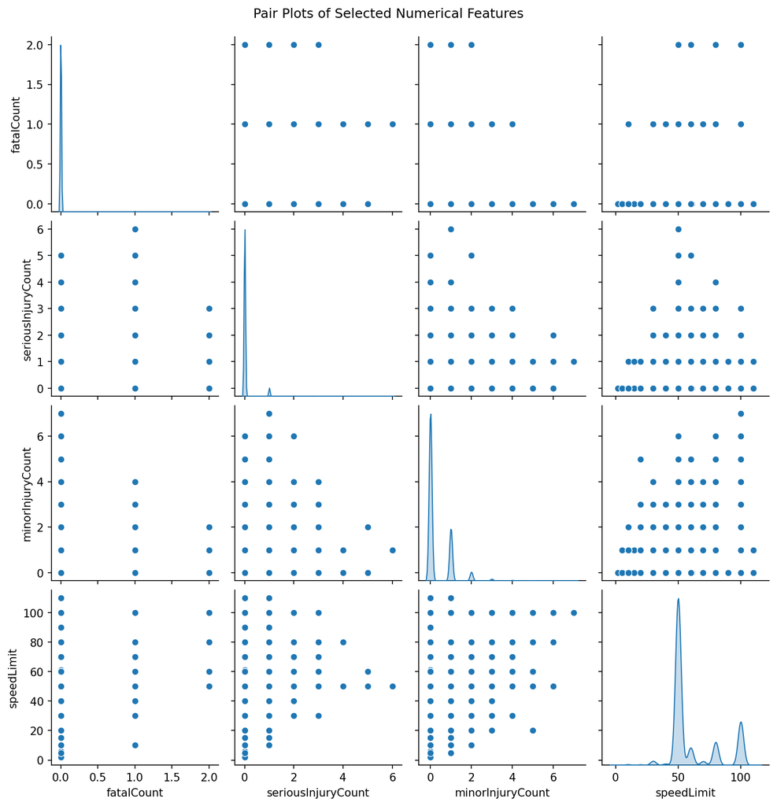

```python
# Select a subset of numerical columns for pair plotting
numeric_cols = ['fatalCount', 'seriousInjuryCount', 'minorInjuryCount', 'speedLimit']
plt.figure(figsize=(7, 3))
sns.pairplot(CAS_AKL18[numeric_cols], diag_kind='kde')
plt.suptitle('Pair Plots of Selected Numerical Features', y=1.02)
plt.show();
```

```python
CAS_AKL18.crashLocation1.value_counts().head(10)
```

```
crashLocation1
SOUTHERN MOTORWAY         2270
GREAT SOUTH ROAD          1732
SH 1N                     1259
NORTHERN MOTORWAY         1108
SOUTH-WESTERN MOTORWAY     879
GREAT NORTH ROAD           828
NORTH-WESTERN MOTORWAY     711
SH 16                      474
DOMINION ROAD              403
SH 20                      340
Name: count, dtype: int64
```

```python
CAS_AKL18.crashSeverity.value_counts()
```

```
crashSeverity
Non-Injury Crash    37571
Minor Crash         14300
Serious Crash        2692
Fatal Crash           244
Name: count, dtype: int64
```

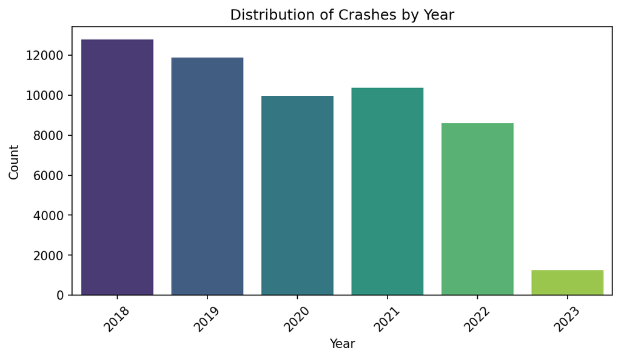

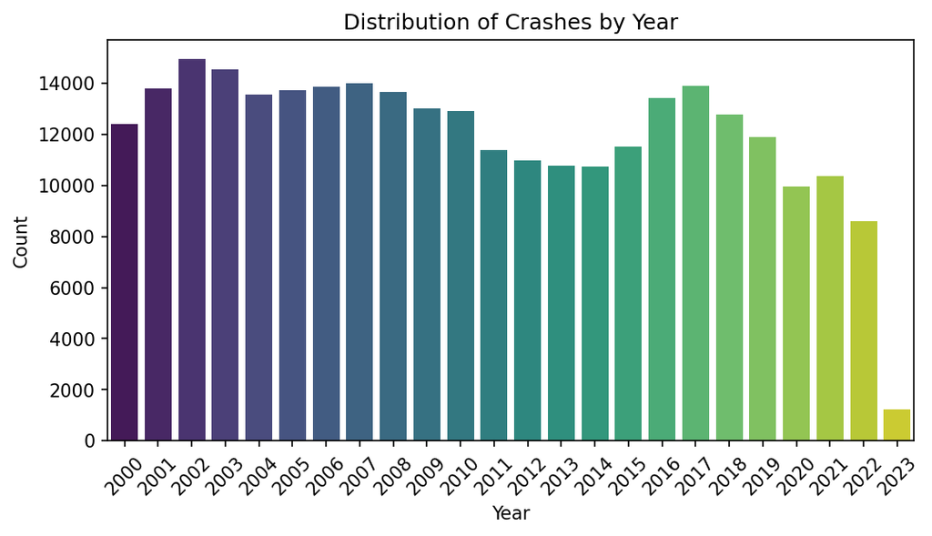

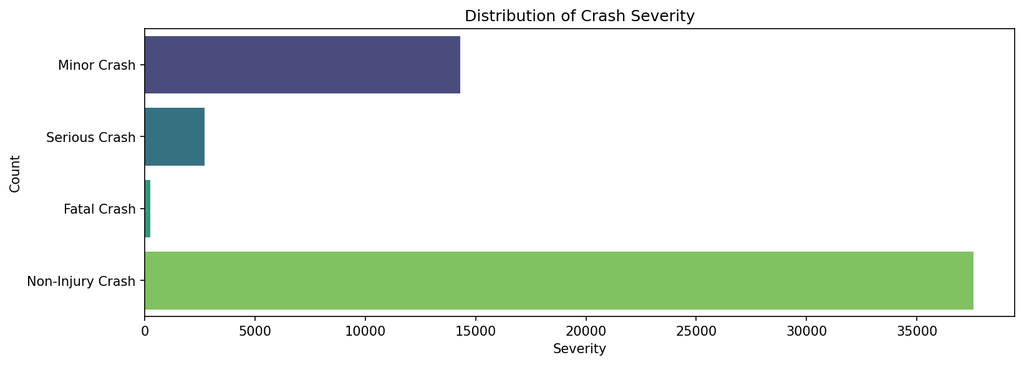

```python
# Distribution of crash years
plt.figure(figsize=(8, 4))
sns.countplot(data=CAS_AKL18, x='crashYear', palette='viridis')
plt.title('Distribution of Crashes by Year')
plt.xlabel('Year')
plt.ylabel('Count')
plt.xticks(rotation=45)
plt.show()

# Distribution of crash years
plt.figure(figsize=(8, 4))
sns.countplot(data=CAS_AKL, x='crashYear', palette='viridis')
plt.title('Distribution of Crashes by Year')
plt.xlabel('Year')
plt.ylabel('Count')
plt.xticks(rotation=45)
plt.show()

# Distribution of crash severity
plt.figure(figsize=(12, 4))
sns.countplot(data=CAS_AKL18, y='crashSeverity', palette='viridis')
plt.title('Distribution of Crash Severity')
plt.xlabel('Severity')
plt.ylabel('Count')
plt.show()
```

Majority of accidents do not involve injuries, and only a small fraction are fatal.

```python
vehicle_cols = ['bicycle', 'bus', 'carStationWagon', 'moped', 'motorcycle',
                   'otherVehicleType', 'schoolBus',
                   'suv', 'taxi', 'truck', 'unknownVehicleType', 'vanOrUtility']
```

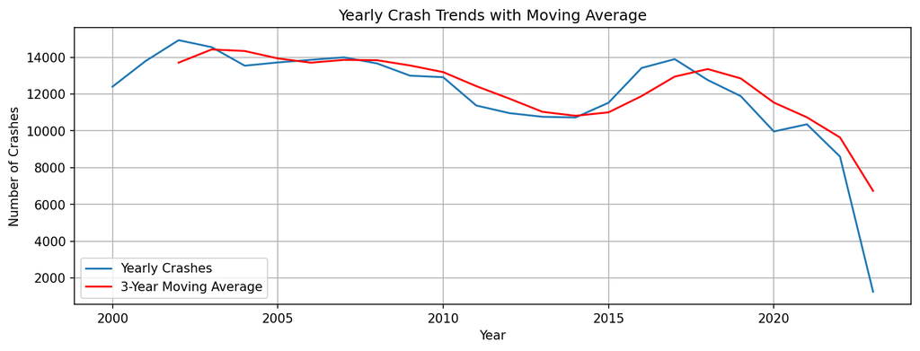

```python
# Aggregate crashes by year
yearly_crashes = CAS_AKL.groupby('crashYear').size()

# Calculate the moving average
moving_avg = yearly_crashes.rolling(window=3).mean()

# Plot yearly crashes and moving average
plt.figure(figsize=(12, 4))
plt.plot(yearly_crashes, label='Yearly Crashes')
plt.plot(moving_avg, label='3-Year Moving Average', color='red')
plt.title('Yearly Crash Trends with Moving Average')
plt.xlabel('Year')
plt.ylabel('Number of Crashes')
plt.legend()
plt.grid(True)
plt.show()
```

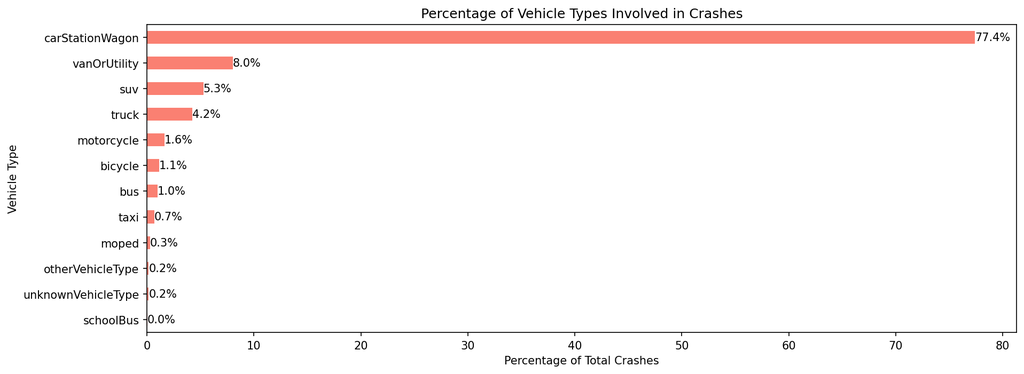

```python
# Sum the occurrences of each vehicle type
vehicle_counts = CAS_AKL[vehicle_cols].sum()

# Calculate the total number of crashes involving any vehicle type
total_crashes = vehicle_counts.sum()

# Calculate the percentage of total crashes for each vehicle type
vehicle_pc = (vehicle_counts / total_crashes) * 100

plt.figure(figsize=(14, 5))
bars = vehicle_pc.sort_values().plot(kind='barh', color='salmon')
for index, value in enumerate(vehicle_pc.sort_values()):
    plt.text(value, index, f'{value:.1f}%', va='center', ha='left')

plt.title('Percentage of Vehicle Types Involved in Crashes')
plt.xlabel('Percentage of Total Crashes')
plt.ylabel('Vehicle Type')
plt.show()
```

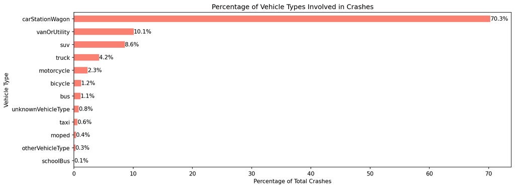

```python
# Sum the occurrences of each vehicle type
vehicle_counts18 = CAS_AKL18[vehicle_cols].sum()

# Calculate the total number of crashes involving any vehicle type
total_crashes18 = vehicle_counts18.sum()

# Calculate the percentage of total crashes for each vehicle type
vehicle_pc18 = (vehicle_counts18 / total_crashes18) * 100

plt.figure(figsize=(14, 5))
bars = vehicle_pc18.sort_values().plot(kind='barh', color='salmon')
for index, value in enumerate(vehicle_pc18.sort_values()):
    plt.text(value, index, f'{value:.1f}%', va='center', ha='left')

plt.title('Percentage of Vehicle Types Involved in Crashes')
plt.xlabel('Percentage of Total Crashes')
plt.ylabel('Vehicle Type')
plt.show()
```

Large majority of traffic accidents involves cars and wagons, but it's visible the progressive percentual increase of vans/utility and SUVs, and also motorbikes when considering only more recent data.

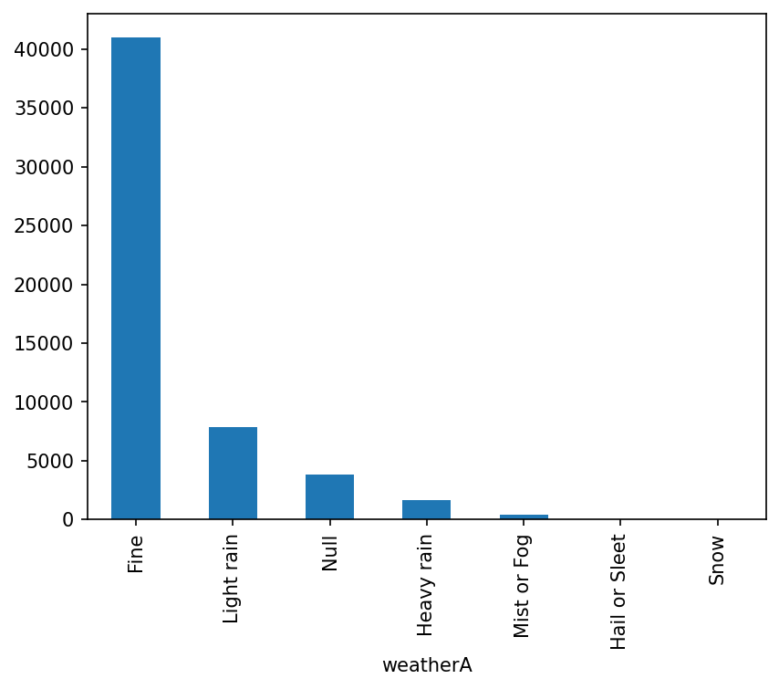

```python
CAS_AKL18.weatherA.value_counts().plot(kind="bar")
```

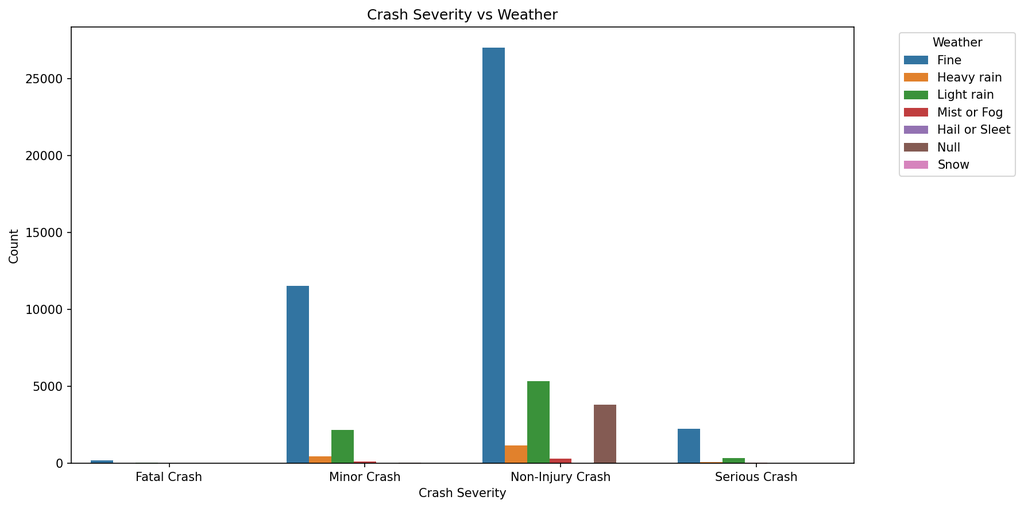

```python
# Grouping the data by crash severity and weather to get the count of each combination
severity_weather_counts = CAS_AKL18.groupby(['crashSeverity', 'weatherA']).size().reset_index(name='count')

# Creating the vertical bar plot
plt.figure(figsize=(12, 6))
sns.barplot(data=severity_weather_counts, x='crashSeverity', y='count', hue='weatherA')
plt.title('Crash Severity vs Weather')
plt.xlabel('Crash Severity')
plt.ylabel('Count')
plt.legend(title='Weather', bbox_to_anchor=(1.05, 1), loc='upper left')
plt.tight_layout()
plt.show()
```

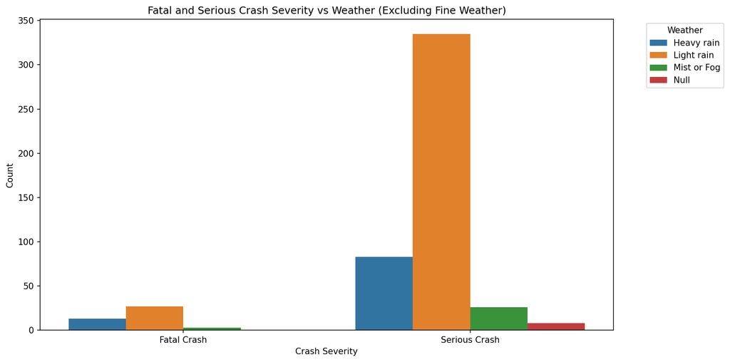

```python
# Filtering out rows where weather is 'Fine' and keeping only 'Fatal Crash' and 'Serious Crash'
filtered_data = CAS_AKL18[(CAS_AKL18['weatherA'] != 'Fine') & (CAS_AKL18['crashSeverity'].isin(['Fatal Crash', 'Serious Crash']))]

# Grouping the data by crash severity and weather to get the count of each combination
severity_weather_counts = filtered_data.groupby(['crashSeverity', 'weatherA']).size().reset_index(name='count')

# Creating the vertical bar plot
plt.figure(figsize=(12, 6))
sns.barplot(data=severity_weather_counts, x='crashSeverity', y='count', hue='weatherA')
plt.title('Fatal and Serious Crash Severity vs Weather (Excluding Fine Weather)')
plt.xlabel('Crash Severity')
plt.ylabel('Count')
plt.legend(title='Weather', bbox_to_anchor=(1.05, 1), loc='upper left')
plt.tight_layout()
plt.show()
```

No apparent large correlation with bad weather conditions and accident severity.

### Clustering Analysis

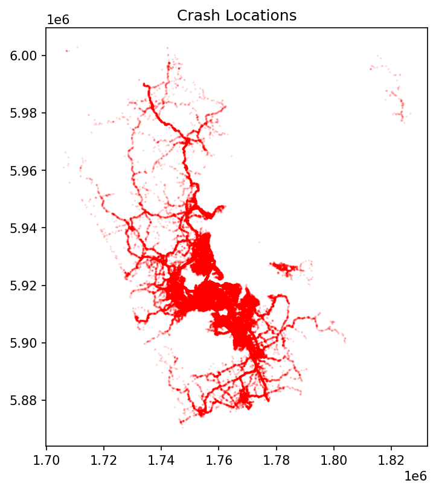

```python
# Convert the crash data to a GeoDataFrame
CAS_AKL['geometry'] = CAS_AKL.apply(lambda row: Point(row['X'], row['Y']), axis=1)
gdf = gpd.GeoDataFrame(CAS_AKL, geometry='geometry')
gdf.crs = "EPSG:2193"

# Plot crash locations
gdf.plot(marker='o', color='red', markersize=0.6, alpha=0.1, figsize=(6, 6))
plt.title('Crash Locations')
plt.show()
```

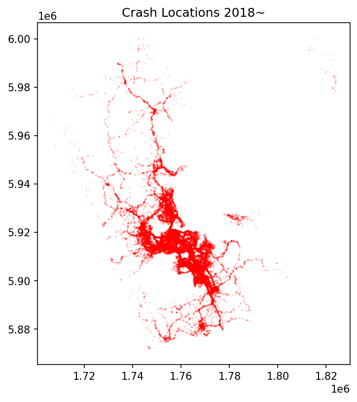

```python
# Convert the crash data to a GeoDataFrame
CAS_AKL18['geometry'] = CAS_AKL18.apply(lambda row: Point(row['X'], row['Y']), axis=1)
gdf18 = gpd.GeoDataFrame(CAS_AKL18, geometry='geometry')
gdf18.crs = "EPSG:2193"

# Plot crash locations
gdf18.plot(marker='o', color='red', markersize=0.6, alpha=0.1, figsize=(6, 6))
plt.title('Crash Locations 2018~')
plt.show()
```

Not much difference between the whole dataset and the subset after 2018.

#### K-means Clustering

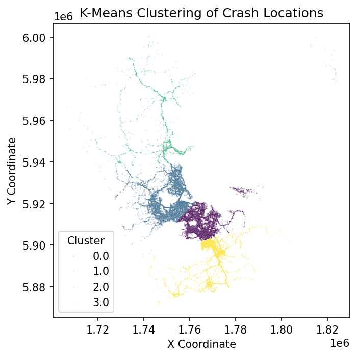

```python
# Extract coordinates for clustering
coords = CAS_AKL18[['X', 'Y']].dropna()
kmeans = KMeans(n_clusters=4, random_state=0, n_init=10).fit(coords)
CAS_AKL18.loc[coords.index, 'cluster'] = kmeans.labels_

# Plot the clusters
plt.figure(figsize=(5, 5))
sns.scatterplot(x='X', y='Y', hue='cluster', alpha=0.2, data=CAS_AKL18, palette='viridis', s=1)
plt.title('K-Means Clustering of Crash Locations')
plt.xlabel('X Coordinate')
plt.ylabel('Y Coordinate')
plt.legend(title='Cluster')
plt.show()
```

K-means clustering seems to be focus on geographic zones rather than specific road areas/spots.

#### DBSCAN Clustering

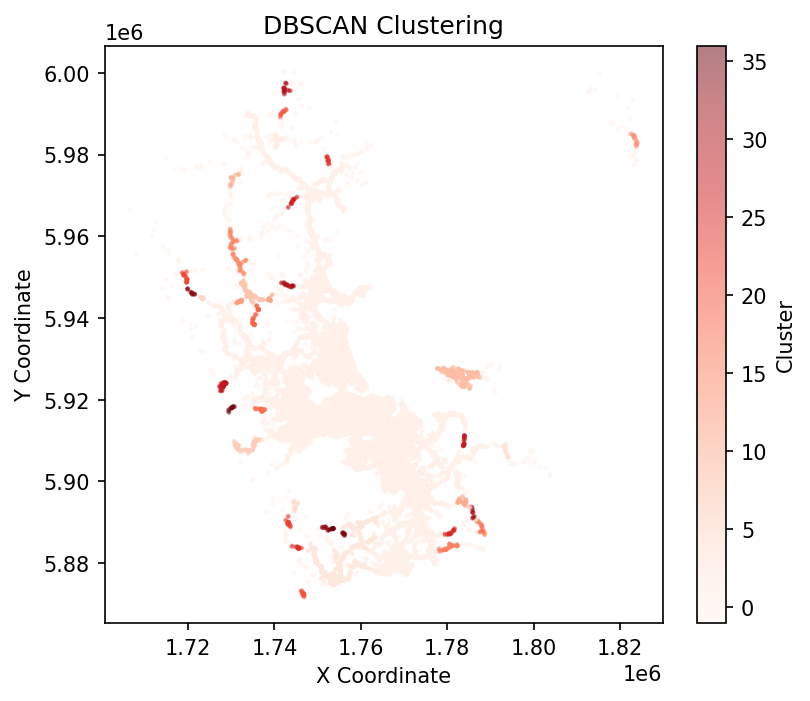

```python
coordinates = CAS_AKL18[['X', 'Y']].dropna()

# Normalize the coordinates
scaler = StandardScaler()
coordinates_norm = scaler.fit_transform(coordinates)

# Apply DBSCAN clustering
db = DBSCAN(eps=0.1, min_samples=8).fit(coordinates_norm)
labels = db.labels_

# Add cluster labels to the dataframe
CAS_AKL18['cluster'] = -1  # Initialize with noise
CAS_AKL18.loc[coordinates.index, 'cluster'] = labels

# Plot clusters
plt.figure(figsize=(6, 5))
plt.scatter(coordinates['X'], coordinates['Y'], c=labels, cmap='Reds', s=2, alpha=0.5)
plt.title(f'DBSCAN Clustering')
plt.xlabel('X Coordinate')
plt.ylabel('Y Coordinate')
plt.colorbar(label='Cluster')
plt.show()
```

DBSCAN clearly indicates the presence of some clustered roads/areas. Time to explore some spatial joins in QGIS.

Although the majority of accidents occur around the city center, will need to look into these cluster areas as they might indicate hotspots.

### Geospatial Density Plots/Heatmap

```python
## FOLIUM NOT DISPLAYING LAYER ON MAP !!

# Prepare heatmap data
#heat_data = list(zip(CAS_AKL18['Y'], CAS_AKL18['X']))

# Create a folium map centered around the given coordinates
#hmap = folium.Map(location=[-36.8485, 174.7633], zoom_start=11)

# Create the HeatMap layer
#HeatMap(heat_data).add_to(hmap)

# Save map as HTML file
#hmap.save('accident_heatmap.html')

# Display the map
#hmap
```

Unfortunately folium does not seem to work well on my machine, the heatmap layer is is not shown (apparently a common issue when using notebooks on macOS).

## KDE

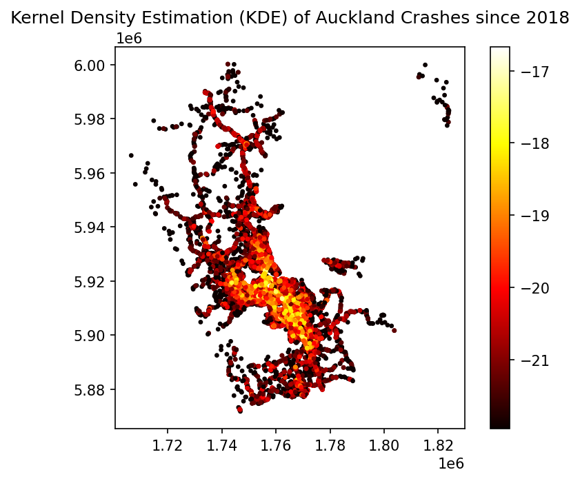

```python
# Perform KDE

CAS_AKL18['geometry'] = CAS_AKL18.apply(lambda row: Point(row['X'], row['Y']), axis=1)
gdf18 = gpd.GeoDataFrame(CAS_AKL18, geometry='geometry')
gdf18.crs = "EPSG:2193"

# Extract valid coordinates
valid_coords = gdf18.dropna(subset=['X', 'Y'])
kde_coords = np.vstack([valid_coords.geometry.x, valid_coords.geometry.y]).T

# Perform KDE
kde = KernelDensity(bandwidth=100, metric='euclidean').fit(kde_coords)
density = kde.score_samples(kde_coords)

# Add density scores to the GeoDataFrame
valid_coords['density'] = density

# Merge the density scores back to the original GeoDataFrame
gdf18 = gdf18.merge(valid_coords[['geometry', 'density']], on='geometry', how='left')

# Plot the KDE heatmap
gdf18.plot(column='density', cmap='hot', legend=True, markersize=5)
plt.title('Kernel Density Estimation (KDE) of Auckland Crashes since 2018')
plt.show()
```

#### Chi-Square Importance for prediction (for ML)

```python
# chi-square algorithm from: http://www.insightsbot.com/blog/2AeuRL/chi-square-feature-selection-in-python

class ChiSquare:
    def __init__(self, dataframe):
        self.df = dataframe
        self.p = None #P-Value
        self.chi2 = None #Chi Test Statistic
        self.dof = None

        self.dfObserved = None
        self.dfExpected = None

    def _print_chisquare_result(self, colX, alpha):
        result = ""
        if self.p < alpha:
            result = f"Column {colX} is an IMPORTANT predictor."
        else:
            result = f"Column {colX} is NOT an important predictor. (Discard {colX} from model)"

        print(result)

    def TestIndependence(self, colX, colY, alpha=0.05):
        X = self.df[colX].astype(str)
        Y = self.df[colY].astype(str)

        self.dfObserved = pd.crosstab(Y, X)
        chi2, p, dof, expected = stats.chi2_contingency(self.dfObserved.values)
        self.p = p
        self.chi2 = chi2
        self.dof = dof

        self.dfExpected = pd.DataFrame(expected, columns=self.dfObserved.columns,
                                       index=self.dfObserved.index)

        self._print_chisquare_result(colX, alpha)

# ChiSquare Class
cT = ChiSquare(CAS_AKL18)

# columns to test
testColumns = [
    'areaUnitID', 'bicycle', 'bus', 'carStationWagon', 'moped', 'motorcycle', 'otherVehicleType',
    'schoolBus', 'suv', 'taxi', 'truck', 'unknownVehicleType', 'vanOrUtility', 'crashSeverity',
    'crashDirectionDescription', 'flatHill', 'light', 'roadCharacter', 'roadLane', 'roadSurface',
    'speedLimit', 'streetLight', 'weatherA', 'weatherB'
]

# chi-square tests
for var in testColumns:
    cT.TestIndependence(colX=var, colY="crashSeverity")
```

```
Column areaUnitID is an IMPORTANT predictor.
Column bicycle is an IMPORTANT predictor.
Column bus is an IMPORTANT predictor.
Column carStationWagon is an IMPORTANT predictor.
Column moped is an IMPORTANT predictor.
Column motorcycle is an IMPORTANT predictor.
Column otherVehicleType is an IMPORTANT predictor.
Column schoolBus is NOT an important predictor. (Discard schoolBus from model)
Column suv is an IMPORTANT predictor.
Column taxi is an IMPORTANT predictor.
Column truck is an IMPORTANT predictor.
Column unknownVehicleType is an IMPORTANT predictor.
Column vanOrUtility is NOT an important predictor. (Discard vanOrUtility from model)
Column crashSeverity is an IMPORTANT predictor.
Column crashDirectionDescription is an IMPORTANT predictor.
Column flatHill is an IMPORTANT predictor.
Column light is an IMPORTANT predictor.
Column roadCharacter is an IMPORTANT predictor.
Column roadLane is an IMPORTANT predictor.
Column roadSurface is an IMPORTANT predictor.
Column speedLimit is an IMPORTANT predictor.
Column streetLight is an IMPORTANT predictor.
Column weatherA is an IMPORTANT predictor.
Column weatherB is an IMPORTANT predictor.
```

Time to move to QGIS and do traffic accidents' hotspot analysis and investigate attributes correlated with accidents.

## Saving CAS Auckland 2018~ to csv to import it into QGIS

```python
# Save CAS_AKL18 DataFrame to a CSV file
CAS_AKL18.to_csv('CAS_AKL18.csv', index=False)
```

# Correlation Analysis

```python
CAS_AKL18 = pd.read_csv('CAS_AKL18.csv')
CAS_AKL = pd.read_csv('CAS_data.csv')
CAS_AKL18.columns
```

```
Index(['X', 'Y', 'OBJECTID', 'areaUnitID', 'bicycle', 'bus', 'carStationWagon',
       'crashDirectionDescription', 'crashFinancialYear', 'crashLocation1',
       'crashLocation2', 'crashSeverity', 'crashSHDescription', 'crashYear',
       'directionRoleDescription', 'fatalCount', 'flatHill', 'light',
       'meshblockId', 'minorInjuryCount', 'moped', 'motorcycle',
       'NumberOfLanes', 'otherVehicleType', 'region', 'roadCharacter',
       'roadLane', 'roadSurface', 'schoolBus', 'seriousInjuryCount',
       'speedLimit', 'streetLight', 'suv', 'taxi', 'tlaId', 'tlaName',
       'trafficControl', 'truck', 'unknownVehicleType', 'urban',
       'vanOrUtility', 'weatherA', 'weatherB', 'vehicle_sum', 'crashWeights',
       'Severity', 'severityIndex', 'geometry', 'cluster'],
      dtype='object')
```

```python
# Create a copy of CAS_AKL18 to work on
cas_df = CAS_AKL18.copy()

# Calculate the crashWeights and severityIndex
cas_df['crashWeights'] = 1 + (5 * cas_df['fatalCount'] + 3 * cas_df['seriousInjuryCount'] + 1 * cas_df['minorInjuryCount']) / 100

severity = {
    'Fatal Crash': 3,
    'Serious Crash': 1.8,
    'Minor Crash': 1.3,
    'Non-Injury Crash': 1,
}
cas_df['Severity'] = cas_df['crashSeverity'].map(severity)

# Calculate the Severity Index
cas_df['severityIndex'] = cas_df['Severity'] * cas_df['crashWeights']
```

```
                         severityIndex  NumberOfLanes  speedLimit   bicycle  \
severityIndex                 1.000000      -0.024038    0.021617  0.145485
NumberOfLanes                -0.024038       1.000000    0.081431       NaN
speedLimit                    0.021617       0.081431    1.000000 -0.084936
bicycle                       0.145485            NaN   -0.084936  1.000000
bus                                NaN       0.043863   -0.052152       NaN
carStationWagon              -0.101431       0.076925   -0.028854 -0.117341
moped                         0.066306       0.014642   -0.049317       NaN
motorcycle                    0.232465       0.010358    0.021485 -0.029044
suv                          -0.033251       0.030249         NaN -0.028061
taxi                               NaN       0.045405   -0.032740       NaN
truck                              NaN       0.032498    0.120558 -0.026910
vanOrUtility                       NaN       0.028110    0.083013 -0.030506
weatherA_Fine                      NaN            NaN         NaN       NaN
weatherA_Hail or Sleet             NaN            NaN         NaN       NaN
weatherA_Heavy rain                NaN            NaN         NaN       NaN
weatherA_Light rain                NaN            NaN    0.010943       NaN
weatherA_Mist or Fog               NaN            NaN         NaN       NaN
weatherA_Null                      NaN            NaN         NaN       NaN
weatherA_Snow                      NaN            NaN         NaN       NaN
roadSurface_End of seal            NaN            NaN         NaN       NaN
roadSurface_Null                   NaN            NaN         NaN       NaN
roadSurface_Sealed                 NaN            NaN         NaN       NaN
roadSurface_Unsealed               NaN            NaN         NaN       NaN
light_Bright sun                   NaN            NaN         NaN       NaN
light_Dark                         NaN            NaN         NaN       NaN
light_Overcast                     NaN            NaN         NaN       NaN
light_Twilight                     NaN            NaN         NaN       NaN
light_Unknown                      NaN            NaN         NaN       NaN

                              bus  carStationWagon     moped  motorcycle  \
severityIndex                 NaN        -0.101431  0.066306    0.232465
NumberOfLanes            0.043863         0.076925  0.014642    0.010358
speedLimit              -0.052152        -0.028854 -0.049317    0.021485
bicycle                       NaN        -0.117341       NaN   -0.029044
bus                      1.000000        -0.099016       NaN   -0.023625
carStationWagon         -0.099016         1.000000 -0.065666   -0.186441
moped                         NaN        -0.065666  1.000000   -0.015183
motorcycle              -0.023625        -0.186441 -0.015183    1.000000
suv                     -0.026879        -0.261313 -0.014650   -0.045831
```

[output cut: 244 more lines]

```
weatherA_Hail or Sleet              NaN            NaN
weatherA_Heavy rain                 NaN      -0.037576
weatherA_Light rain           -0.012522      -0.086506
weatherA_Mist or Fog           0.010577      -0.020552
weatherA_Null                 -0.037209       0.756919
weatherA_Snow                       NaN            NaN
roadSurface_End of seal             NaN            NaN
roadSurface_Null              -0.015639       0.281798
roadSurface_Sealed                  NaN      -0.184562
roadSurface_Unsealed                NaN      -0.014681
light_Bright sun              -0.158710      -0.170737
light_Dark                    -0.148201      -0.159431
light_Overcast                -0.134176      -0.144344
light_Twilight                 1.000000      -0.054532
light_Unknown                 -0.054532       1.000000
```

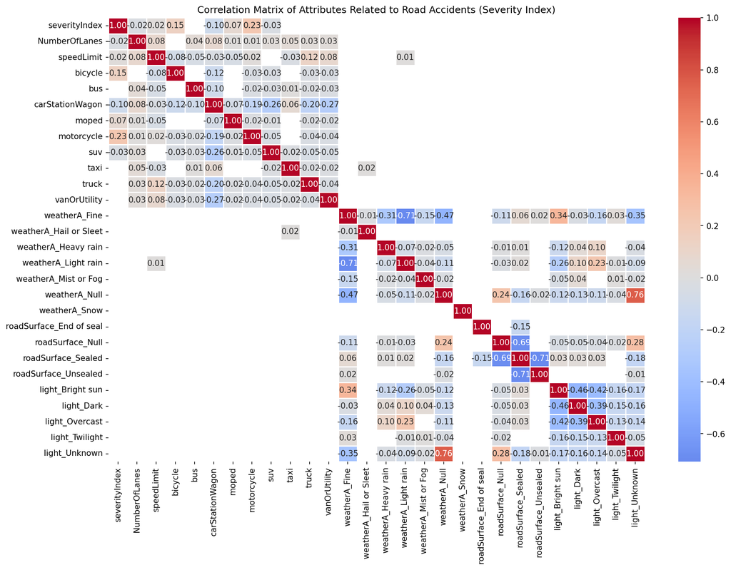

```python
relevant_cols = [
    'severityIndex','NumberOfLanes', 'speedLimit', 'bicycle', 'bus', 'carStationWagon',
    'moped', 'motorcycle', 'suv', 'taxi', 'truck', 'vanOrUtility',
]
categorical_cols = ['weatherA', 'roadSurface', 'light']

# Drop rows with missing values in relevant columns
cas_df.dropna(subset=relevant_cols, inplace=True)

# Encode categorical variables
encoder = OneHotEncoder(sparse_output=False)
encoded_vars = encoder.fit_transform(cas_df[categorical_cols])
encoded_df = pd.DataFrame(encoded_vars, columns=encoder.get_feature_names_out(categorical_cols))

cas_df = cas_df.join(encoded_df).drop(columns=categorical_cols)
relevant_cols.extend(encoder.get_feature_names_out(categorical_cols))

# Standardise the numerical values
scaler = StandardScaler()
scaled_values = scaler.fit_transform(cas_df[relevant_cols])
scaled_df = pd.DataFrame(scaled_values, columns=relevant_cols)

corr_matrix = scaled_df.corr()

# Mask the correlations (skip if between -1% and 1%)
mask = (corr_matrix > -0.01) & (corr_matrix < 0.01)
masked_corr_matrix = corr_matrix.mask(mask)

print(masked_corr_matrix)

plt.figure(figsize=(15, 10))
sns.heatmap(masked_corr_matrix, annot=True, cmap='coolwarm', center=0, linewidths=0.5, fmt='.2f')
plt.title('Correlation Matrix of Attributes Related to Road Accidents (Severity Index)')
plt.show()
```

Correlations of accident severity index and weather, road surface and light are too weak.

```
                 severityIndex  NumberOfLanes  speedLimit   bicycle       bus  \
severityIndex         1.000000      -0.024038    0.021617  0.145485  0.002121
NumberOfLanes        -0.024038       1.000000    0.081431 -0.005382  0.043863
speedLimit            0.021617       0.081431    1.000000 -0.084936 -0.052152
bicycle               0.145485      -0.005382   -0.084936  1.000000  0.001337
bus                   0.002121       0.043863   -0.052152  0.001337  1.000000
carStationWagon      -0.101431       0.076925   -0.028854 -0.117341 -0.099016
moped                 0.066306       0.014642   -0.049317 -0.009473  0.000027
motorcycle            0.232465       0.010358    0.021485 -0.029044 -0.023625
suv                  -0.033251       0.030249   -0.006059 -0.028061 -0.026879
taxi                  0.000397       0.045405   -0.032740  0.004923  0.014454
truck                -0.007648       0.032498    0.120558 -0.026910 -0.016970
vanOrUtility          0.003340       0.028110    0.083013 -0.030506 -0.027138

                 carStationWagon     moped  motorcycle       suv      taxi  \
severityIndex          -0.101431  0.066306    0.232465 -0.033251  0.000397
NumberOfLanes           0.076925  0.014642    0.010358  0.030249  0.045405
speedLimit             -0.028854 -0.049317    0.021485 -0.006059 -0.032740
bicycle                -0.117341 -0.009473   -0.029044 -0.028061  0.004923
bus                    -0.099016  0.000027   -0.023625 -0.026879  0.014454
carStationWagon         1.000000 -0.065666   -0.186441 -0.261313  0.059968
moped                  -0.065666  1.000000   -0.015183 -0.014650  0.005674
motorcycle             -0.186441 -0.015183    1.000000 -0.045831 -0.003397
suv                    -0.261313 -0.014650   -0.045831  1.000000 -0.017053
taxi                    0.059968  0.005674   -0.003397 -0.017053  1.000000
truck                  -0.202780 -0.018617   -0.038369 -0.048631 -0.015199
vanOrUtility           -0.269986 -0.020761   -0.038920 -0.046696 -0.017835

                    truck  vanOrUtility
severityIndex   -0.007648      0.003340
NumberOfLanes    0.032498      0.028110
speedLimit       0.120558      0.083013
bicycle         -0.026910     -0.030506
bus             -0.016970     -0.027138
carStationWagon -0.202780     -0.269986
moped           -0.018617     -0.020761
motorcycle      -0.038369     -0.038920
suv             -0.048631     -0.046696
taxi            -0.015199     -0.017835
truck            1.000000     -0.036952
vanOrUtility    -0.036952      1.000000
```

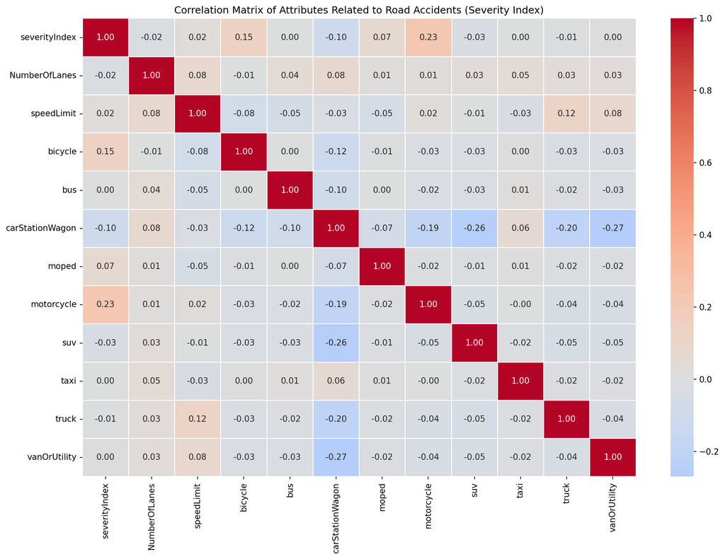

```python
relevant_cols = [
    'severityIndex', 'NumberOfLanes', 'speedLimit', 'bicycle', 'bus',
    'carStationWagon', 'moped', 'motorcycle', 'suv', 'taxi', 'truck', 'vanOrUtility'
]

# Create a copy of CAS_AKL18 to work on
cas_df1 = CAS_AKL18.copy()

# Drop rows with missing values in relevant columns
cas_df1.dropna(subset=relevant_cols, inplace=True)

# Standardise the numerical values
scaler = StandardScaler()
scaled_values = scaler.fit_transform(cas_df1[relevant_cols])
scaled_df = pd.DataFrame(scaled_values, columns=relevant_cols)

corr_matrix = scaled_df.corr()
print(corr_matrix)

plt.figure(figsize=(15, 10))
sns.heatmap(corr_matrix, annot=True, cmap='coolwarm', center=0, linewidths=0.2, fmt='.2f')
plt.title('Correlation Matrix of Attributes Related to Road Accidents (Severity Index)')
plt.show()
```

Motorcycle (0.232): The severity index shows the highest positive correlation with motorcycle involvement in accidents. This suggests that accidents involving motorcycles tend to have higher severity. Bicycle (0.145): There is a moderate positive correlation between the severity index and bicycle involvement, indicating that bicycle-related accidents also tend to be more severe. Moped (0.066): A positive but weaker correlation with mopeds is observed, suggesting some level of severity in moped-related accidents. Car Station Wagon (-0.101): A negative correlation with car station wagons indicates that accidents involving this type of vehicle tend to be less severe.

Motorcycles and Bicycles are more strongly associated with higher severity accidents.

```python
file_paths = [
    "Crashes_by_AvgDTraffic.shp",
    "2018-census-household-total-new-zealand-by-statistical-area-.shp"
]

# Function to load and print columns of a shapefile
def print_columns(file_path):
    gdf = gpd.read_file(file_path)

    # Check for and handle multiple geometry columns
    geometry_cols = gdf.columns[gdf.columns.str.contains('geometry')]
    if len(geometry_cols) > 1:
        for i, col in enumerate(geometry_cols):
            if i == 0:
                continue
            gdf.rename(columns={col: f'geometry_{i}'}, inplace=True)

    print(f"Columns in {file_path.split('/')[-1]}:")
    print(gdf.columns)
    print("\n")

# Iterate over file paths and print columns
for file_path in file_paths:
    try:
        print_columns(file_path)
    except ValueError as e:
        print(f"Error loading {file_path}: {e}")
```

```
Columns in Crashes_by_AvgDTraffic.shp:
Index(['OBJECTID', 'carr_way_n', 'road_id', 'road_name', 'start_name',
       'end_name', 'cway_width', 'traff_mana', 'Shape__Len', 'RoadTraffi',
       'RoadTraf_1', 'RoadTraf_2', 'severityIn', 'severity_1', 'severity_2',
       'SI_ADTnorm', 'numSI_ADT', 'normSI_ADT', 'geometry'],
      dtype='object')


Columns in 2018-census-household-total-new-zealand-by-statistical-area-.shp:
Index(['SA12018_V1', 'C18_HHLDS_', 'C18_Tenure', 'C18_Tenu_1', 'C18_Tenu_2',
       'C18_Tenu_3', 'C18_Tenu_4', 'C18_Tenu_5', 'C18_Tenu_6', 'C18_Landlo',
       'C18_Land_1', 'C18_Land_2', 'C18_Land_3', 'C18_Land_4', 'C18_Land_5',
       'C18_Land_6', 'C18_Land_7', 'C18_Land_8', 'C18_WeekRe', 'C18_Week_1',
       'C18_Week_2', 'C18_Week_3', 'C18_Week_4', 'C18_Week_5', 'C18_Week_6',
       'C18_Week_7', 'C18_Week_8', 'C18_Week_9', 'C18_Week10', 'C18_Week11',
       'C18_MotorV', 'C18_Moto_1', 'C18_Moto_2', 'C18_Moto_3', 'C18_Moto_4',
       'C18_Moto_5', 'C18_Moto_6', 'C18_Moto_7', 'C18_Moto_8', 'LANDWATER',
       'LANDWATER_', 'LAND_AREA_', 'AREA_SQ_KM', 'SHAPE_Leng', 'geometry'],
      dtype='object')
```

```python
# Load additional shapefiles
traffic_gdf = gpd.read_file('Crashes_by_AvgDTraffic.shp')
census_gdf = gpd.read_file('2018-census-household-total-new-zealand-by-statistical-area-.shp')

# Ensure CRS is consistent
traffic_gdf = traffic_gdf.to_crs(epsg=2193)
census_gdf = census_gdf.to_crs(epsg=2193)

# Convert CAS data to GeoDataFrame
cas_gdf = gpd.GeoDataFrame(cas_df, geometry=gpd.points_from_xy(cas_df.X, cas_df.Y), crs='EPSG:2193')

# Spatial join CAS data with traffic volume data
merged_gdf = gpd.sjoin(cas_gdf, traffic_gdf, how='left', predicate='intersects', lsuffix='_left', rsuffix='_traffic')

# Spatial join the result with census data
merged_gdf = gpd.sjoin(merged_gdf, census_gdf, how='left', predicate='intersects', lsuffix='_final', rsuffix='_census')
```

```python
merged_gdf
```

|  | X | Y | OBJECTID__left | areaUnitID | bicycle | bus | carStationWagon | crashDirectionDescription | crashFinancialYear | crashLocation1 | crashLocation2 | crashSeverity | crashSHDescription | crashYear | directionRoleDescription | ... | C18_Week11 | C18_MotorV | C18_Moto_1 | C18_Moto_2 | C18_Moto_3 | C18_Moto_4 | C18_Moto_5 | C18_Moto_6 | C18_Moto_7 | C18_Moto_8 | LANDWATER | LANDWATER_ | LAND_AREA_ | … |
| --- | --- | --- | --- | --- | --- | --- | --- | --- | --- | --- | --- | --- | --- | --- | --- | --- | --- | --- | --- | --- | --- | --- | --- | --- | --- | --- | --- | --- | --- | --- |
| 0 | 1.754689e+06 | 5.924770e+06 | 141653 | 509800.0 | 0.0 | 0.0 | 3.0 | East | 2017/2018 | ONEWA ROAD | KAURI GLEN ROAD | Minor Crash | No | 2018 | East | ... | -999 | 0 | 12 | 12 | 3 | 0 | 0 | 30 | 3 | 30 | 12 | Mainland | 0.225556 | … |
| 1 | 1.763714e+06 | 5.913506e+06 | 141723 | 520402.0 | 0.0 | 0.0 | 1.0 | North | 2018/2019 | MOUNT WELLINGTON HIGHWAY | HAMLIN ROAD | Serious Crash | No | 2018 | South | ... | 450 | 3 | 18 | 24 | 6 | 3 | 0 | 48 | 3 | 51 | 12 | Mainland | 0.031501 | … |
| 2 | 1.762166e+06 | 5.906172e+06 | 141727 | 524200.0 | 0.0 | 0.0 | 2.0 | South | 2018/2019 | SH 20 | MASSEY OFF NBD | Minor Crash | Yes | 2018 | North | ... | 140 | 0 | 3 | 6 | 3 | 3 | 3 | 12 | 6 | 18 | 12 | Mainland | 1.814258 | … |
| 3 | 1.756323e+06 | 5.927364e+06 | 141728 | 507900.0 | 0.0 | 0.0 | 3.0 | South | 2017/2018 | SH 1N | NORTHCOTE OFF SBD | Minor Crash | Yes | 2018 | South | ... | -999 | -999 | -999 | -999 | -999 | -999 | -999 | -999 | -999 | 0 | 12 | Mainland | 0.333007 | … |
| 4 | 1.765783e+06 | 5.906821e+06 | 141750 | 522301.0 | 0.0 | 0.0 | 1.0 | East | 2018/2019 | HOTEO AVENUE | GREAT SOUTH ROAD | Minor Crash | No | 2018 | East | ... | 420 | 3 | 15 | 21 | 3 | 0 | 0 | 45 | 9 | 54 | 12 | Mainland | 0.041076 | … |
| ... | ... | ... | ... | ... | ... | ... | ... | ... | ... | ... | ... | ... | ... | ... | ... | ... | ... | ... | ... | ... | ... | ... | ... | ... | ... | ... | ... | ... | ... | … |
| 54802 | 1.743947e+06 | 5.924009e+06 | 1318956 | 513511.0 | 0.0 | 0.0 | 2.0 | Null | 2022/2023 | FRED TAYLOR DRIVE | HOBSONVILLE ROAD | Minor Crash | No | 2023 | South | ... | 500 | -999 | -999 | -999 | -999 | -999 | -999 | 12 | -999 | 15 | 12 | Mainland | 1.863416 | … |
| 54803 | 1.768891e+06 | 5.904246e+06 | 1318957 | 523820.0 | 0.0 | 0.0 | 2.0 | Null | 2022/2023 | RANSOM SMYTH DRIVE | PALMETTO PLACE | Non-Injury Crash | No | 2022 | East | ... | 580 | 3 | 3 | 12 | 9 | 9 | 3 | 39 | 3 | 42 | 12 | Mainland | 0.039397 | … |
| 54804 | 1.757918e+06 | 5.914599e+06 | 1318959 | 518600.0 | 0.0 | 0.0 | 2.0 | South | 2022/2023 | PAH ROAD | PUKEHANA AVENUE | Non-Injury Crash | No | 2022 | North | ... | 550 | 0 | 12 | 21 | 6 | 3 | 3 | 45 | 0 | 45 | 12 | Mainland | 0.031601 | … |
| 54805 | 1.758255e+06 | 5.918060e+06 | 1318961 | 517400.0 | 0.0 | 0.0 | 1.0 | East | 2022/2023 | MORROW STREET | GILLIES AVENUE | Non-Injury Crash | No | 2022 | East | ... | -999 | -999 | -999 | -999 | -999 | -999 | -999 | -999 | -999 | 3 | 12 | Mainland | 0.296909 | … |
| 54806 | 1.754396e+06 | 5.875116e+06 | 1318963 | 526104.0 | 0.0 | 0.0 | 1.0 | Null | 2022/2023 | KAIWAKA ROAD | COLOMBO ROAD | Non-Injury Crash | No | 2022 | East | ... | 450 | 0 | 18 | 24 | 12 | 3 | 3 | 60 | 3 | 63 | 12 | Mainland | 0.071830 | … |

67920 rows × 126 columns

```
               severityIndex  cway_width  RoadTraf_1  numSI_ADT  normSI_ADT  \
severityIndex       1.000000   -0.034661   -0.059568   0.026185    0.009931
cway_width         -0.034661    1.000000    0.427513  -0.164032   -0.064547
RoadTraf_1         -0.059568    0.427513    1.000000  -0.178104   -0.149014
numSI_ADT           0.026185   -0.164032   -0.178104   1.000000    0.768449
normSI_ADT          0.009931   -0.064547   -0.149014   0.768449    1.000000
C18_Moto_8          0.023313    0.022613   -0.131712   0.000775    0.017281

               C18_Moto_8
severityIndex    0.023313
cway_width       0.022613
RoadTraf_1      -0.131712
numSI_ADT        0.000775
normSI_ADT       0.017281
C18_Moto_8       1.000000
```

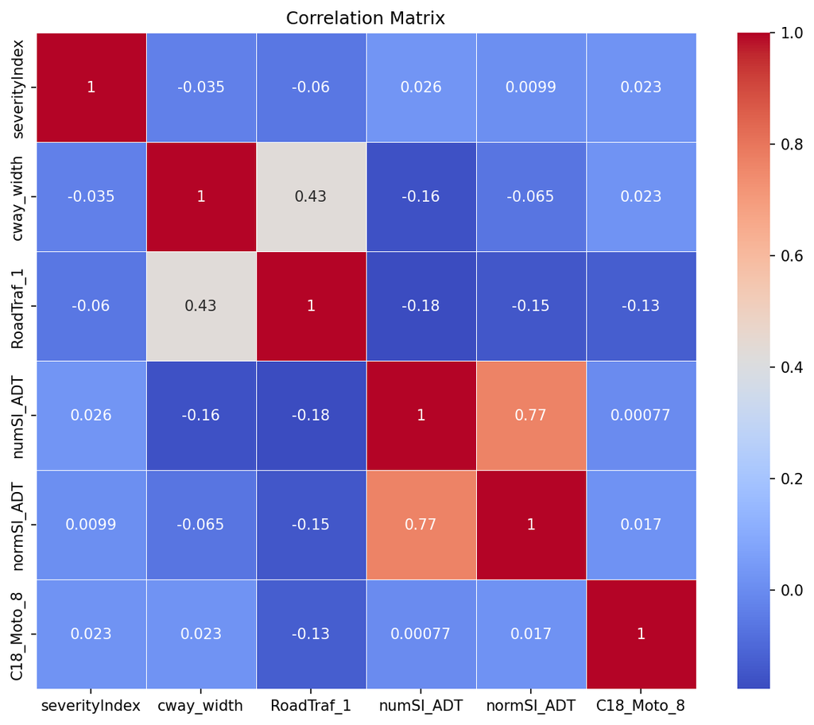

```python
# Select columns for correlation analysis, including relevant columns from additional shapefiles
corr_columns = ['severityIndex', 'cway_width', 'RoadTraf_1', 'numSI_ADT', 'normSI_ADT', 'C18_Moto_8']

# Drop rows with missing values in the selected columns
merged_gdf = merged_gdf.dropna(subset=corr_columns)


# Standardise the values
scaler = StandardScaler()
scaled_values = scaler.fit_transform(merged_gdf[corr_columns])
scaled_df = pd.DataFrame(scaled_values, columns=corr_columns)

# Calculate correlation matrix
correlation_matrix = scaled_df.corr()

# Display the correlation matrix
print(correlation_matrix)

# Visualize the correlation matrix
plt.figure(figsize=(10, 8))
sns.heatmap(correlation_matrix, annot=True, cmap='coolwarm', linewidths=0.3)
plt.title('Correlation Matrix')
plt.show()
```

cway is the carriage width, road width

roadTraf_1 is the avg daily traffic

numSI_ADT is the SeverityIndex normalised by the avg daily traffic and number of accidents in that road section

normSI_ADT is the SeverityIndex normalised by the avg daily traffic and road section length and number of accidents in that road section

C18_Moto_8 is the number of vehicles per household

RoadTraf_1 (-0.060): A weak negative correlation with average daily traffic suggests that roads with higher daily traffic might not necessarily correspond to higher accident severity.

Cway_width (-0.035): A weak negative correlation with carriage width suggests that narrower roads might experience slightly more severe accidents.